# Analysis of N400 amplitude data from two experiments on processing of gender-related stereotypes

## 3.2 Dataset structure and summary

Overview of the final dataset of Experiment 1.

```r
# Dataset dimensions
cat("Dataset Dimensions:\n")
```

```
## Dataset Dimensions:
```

```r
cat(sprintf("  Total observations: %d\n", nrow(exp1_all_data)))
```

```
##   Total observations: 134322
```

```r
cat(sprintf("  Total variables: %d\n", ncol(exp1_all_data)))
```

```
##   Total variables: 18
```

```r
cat(sprintf("  Unique participants: %d\n", n_distinct(exp1_all_data$ParticipantID)))
```

```
##   Unique participants: 62
```

```r
cat(sprintf("  Unique items: %d\n", n_distinct(exp1_all_data$WordID)))
```

```
##   Unique items: 200
```

```r
# Trial counts by condition
cat("\nTrials per Condition:\n")
```

```
##
## Trials per Condition:
```

```r
count_trial <- compute_trial_counts(exp1_all_data)

exp1_trial_summary <- count_trial %>%
  group_by(Condition) %>%
  summarise(
    n_participants = n(),
    mean_trials = mean(trial, na.rm = TRUE),
    sd_trials = sd(trial, na.rm = TRUE),
    min_trials = min(trial, na.rm = TRUE),
    max_trials = max(trial, na.rm = TRUE),
    .groups = "drop"
  )

for (i in 1:nrow(exp1_trial_summary)) {
  cat(sprintf("  %s: %d participants, M = %.1f trials (SD = %.1f, range: %d-%d)\n",
              exp1_trial_summary$Condition[i],
              exp1_trial_summary$n_participants[i],
              exp1_trial_summary$mean_trials[i],
              exp1_trial_summary$sd_trials[i],
              exp1_trial_summary$min_trials[i],
              exp1_trial_summary$max_trials[i]))
}
```

```
##   Semantics.Congruent: 62 participants, M = 36.0 trials (SD = 5.1, range: 20-40)
##   Semantics.Incongruent: 62 participants, M = 36.3 trials (SD = 4.8, range: 20-40)
##   Sexuality.Congruent.Atypical: 62 participants, M = 71.8 trials (SD = 9.8, range: 41-80)
##   Sexuality.Congruent.Typical: 62 participants, M = 72.3 trials (SD = 9.8, range: 39-80)
##   Sexuality.Incongruent.Atypical: 62 participants, M = 72.7 trials (SD = 8.9, range: 38-80)
##   Sexuality.Incongruent.Typical: 62 participants, M = 72.1 trials (SD = 9.4, range: 41-80)
```

```r
# Categorical variables used in models
cat("\n\nCategorical Variables (Levels):\n")
```

```
##
##
## Categorical Variables (Levels):
```

```r
cat(sprintf("  Participant Gender: %s\n", paste(levels(exp1_all_data$PtpGender), collapse = ", ")))
```

```
##   Participant Gender: Female, Male
```

```r
cat(sprintf("  Congruency: %s\n", paste(levels(exp1_all_data$Congruency), collapse = ", ")))
```

```
##   Congruency: Incongruent, Congruent
```

```r
cat(sprintf("  VoiceGenderedness: %s\n", paste(levels(exp1_all_data$VoiceGenderedness), collapse = ", ")))
```

```
##   VoiceGenderedness: High, Low
```

```r
cat(sprintf("  Electrode Regions (Frontality): %s\n", paste(unique(exp1_all_data$Frontality), collapse = ", ")))
```

```
##   Electrode Regions (Frontality): C, CP
```

```r
# Continuous variables used in models
cat("\n\nContinuous Variables Summary:\n")
```

```
##
##
## Continuous Variables Summary:
```

```r
cat("\nDependent Variable:\n")
```

```
##
## Dependent Variable:
```

```r
print(summary(exp1_all_data$value))
```

```
##    Min. 1st Qu.  Median    Mean 3rd Qu.    Max.
## -57.990  -2.919   2.659   2.772   8.391  59.198
```

```r
cat("\nTrial Order (original and centered):\n")
```

```
##
## Trial Order (original and centered):
```

```r
cat(sprintf("  Order: Range = [%d, %d], Mean = %.2f\n",
            min(exp1_all_data$Order), max(exp1_all_data$Order), mean(exp1_all_data$Order)))
```

```
##   Order: Range = [1, 400], Mean = 201.62
```

```r
# Center Order variable for models
exp1_all_data <- exp1_all_data %>%
  mutate(Order_c = Order - mean(Order))

cat(sprintf("  Order_c (centered): Range = [%.2f, %.2f], Mean = %.2f\n",
            min(exp1_all_data$Order_c), max(exp1_all_data$Order_c), mean(exp1_all_data$Order_c)))
```

```
##   Order_c (centered): Range = [-200.62, 198.38], Mean = -0.00
```

```r
# Random effects variables
cat("\n\nRandom Effects Grouping Variables:\n")
```

```
##
##
## Random Effects Grouping Variables:
```

```r
cat(sprintf("  Participants (ParticipantID): %d levels\n", n_distinct(exp1_all_data$ParticipantID)))
```

```
##   Participants (ParticipantID): 62 levels
```

```r
cat(sprintf("  Items (WordID): %d levels\n", n_distinct(exp1_all_data$WordID)))
```

```
##   Items (WordID): 200 levels
```

```r
cat(sprintf("  Electrode Channels (ChLabel): %d levels\n", n_distinct(exp1_all_data$ChLabel)))
```

```
##   Electrode Channels (ChLabel): 6 levels
```

```r
cat("\n\nDataset ready for statistical modeling.\n")
```

```
##
##
## Dataset ready for statistical modeling.
```

## 3.3 Semantic trials

### 3.3.1 Simple effect of Congruency for semantic violation.

```r
# 1. Build a model with maximal fixed effects structure based on the experimental design and simplest random structure with random intercepts for ParticipantID, WordID and ChLabel.
exp1_model_semantics_main <- run_lmer_model(
  value ~ Congruency +
    (1 | ParticipantID) + (1 | WordID) + (1 | ChLabel),
  data = exp1_data_semantics,
  auto_simplify = FALSE,
  time_limit = 300
)
```

```
## Linear mixed model fit by maximum likelihood . t-tests use Satterthwaite's
##   method [lmerModLmerTest]
## Formula: formula
##    Data: data
## Control: control
##
##       AIC       BIC    logLik -2*log(L)  df.resid
##  189511.8  189561.0  -94749.9  189499.8     26868
##
## Scaled residuals:
##     Min      1Q  Median      3Q     Max
## -5.2190 -0.6529 -0.0181  0.6520  4.0477
##
## Random effects:
##  Groups        Name        Variance Std.Dev.
##  ParticipantID (Intercept)  8.77242 2.9618
##  WordID        (Intercept)  1.44876 1.2036
##  ChLabel       (Intercept)  0.08053 0.2838
##  Residual                  66.67677 8.1656
## Number of obs: 26874, groups:  ParticipantID, 62; WordID, 40; ChLabel, 6
##
## Fixed effects:
##               Estimate Std. Error         df t value Pr(>|t|)
## (Intercept)     1.7229     0.4401    88.3354   3.915 0.000178 ***
## Congruency1    -1.3031     0.0997 26771.3668 -13.071  < 2e-16 ***
## ---
## Signif. codes:  0 '***' 0.001 '**' 0.01 '*' 0.05 '.' 0.1 ' ' 1
##
## Correlation of Fixed Effects:
##             (Intr)
## Congruency1 -0.001
##
## Analysis of Deviance Table (Type III Wald chisquare tests)
##
## Response: value
##               Chisq Df Pr(>Chisq)
## (Intercept)  15.327  1  0.0000904 ***
## Congruency  170.846  1  < 2.2e-16 ***
## ---
## Signif. codes:  0 '***' 0.001 '**' 0.01 '*' 0.05 '.' 0.1 ' ' 1
```

```r
# 2. Augment random effects structure by adding random slopes for Congruency for ParticipantID and WordID, while keeping the same fixed effects structure.
exp1_model_semantics_main <- run_lmer_model(
  value ~ Congruency  +
    (1 + Congruency | ParticipantID) + (1 + Congruency | WordID) + (1 | ChLabel),
  data = exp1_data_semantics,
  auto_simplify = TRUE,
  time_limit = 600
)
```

```
## ======================================================
## === Searching for optimal RE structure
## === Fixed effects: value ~ Congruency
## ======================================================
##
## Testing 3 candidate RE structure(s)...
##
## [1/3] maximal (correlated)
##        RE:  (1 + Congruency | ParticipantID) + (1 + Congruency | WordID) + (1 | ChLabel)
##   -> Singular: FALSE | Max scaled gradient: 0.00000 | Optimizer warnings: FALSE
##   -> OPTIMAL: converged. Using this RE structure.
##
##   Re-fitting with REML = TRUE...
## ======================================================
## === Optimal RE structure found: maximal (correlated)
## ======================================================
##
## Linear mixed model fit by REML. t-tests use Satterthwaite's method [
## lmerModLmerTest]
## Formula: refit_formula
##    Data: data
## Control: control
##
## REML criterion at convergence: 189178.8
##
## Scaled residuals:
##     Min      1Q  Median      3Q     Max
## -5.4831 -0.6508 -0.0185  0.6491  3.9944
##
## Random effects:
##  Groups        Name        Variance Std.Dev. Corr
##  ParticipantID (Intercept)  8.95321 2.992
##                Congruency1  2.05138 1.432    -0.11
##  WordID        (Intercept)  1.46854 1.212
##                Congruency1  3.00271 1.733    -0.42
##  ChLabel       (Intercept)  0.08237 0.287
##  Residual                  65.46546 8.091
## Number of obs: 26874, groups:  ParticipantID, 62; WordID, 40; ChLabel, 6
##
## Fixed effects:
##             Estimate Std. Error      df t value Pr(>|t|)
## (Intercept)   1.7181     0.4442 87.2430   3.867 0.000211 ***
## Congruency1  -1.2773     0.3437 64.4845  -3.717 0.000424 ***
## ---
## Signif. codes:  0 '***' 0.001 '**' 0.01 '*' 0.05 '.' 0.1 ' ' 1
##
## Correlation of Fixed Effects:
##             (Intr)
## Congruency1 -0.195
##
## Analysis of Deviance Table (Type III Wald chisquare tests)
##
## Response: value
##              Chisq Df Pr(>Chisq)
## (Intercept) 14.957  1  0.0001100 ***
## Congruency  13.815  1  0.0002017 ***
## ---
## Signif. codes:  0 '***' 0.001 '**' 0.01 '*' 0.05 '.' 0.1 ' ' 1
```

Plot the mean N400 amplitudes separated by Congruency (Fig.2a).

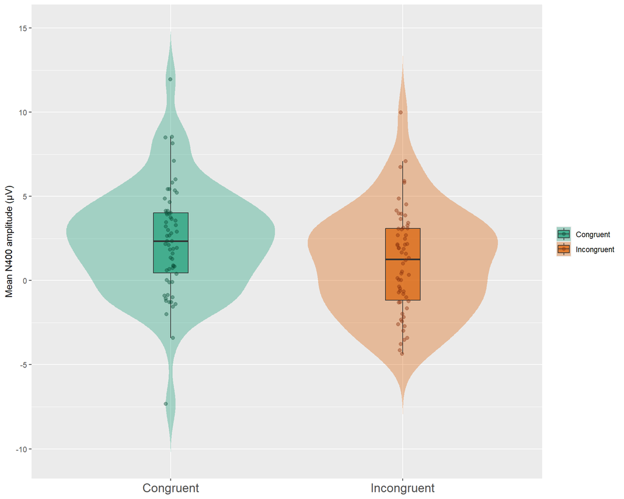

```r
plot_data <- exp1_data_semantics %>%
  group_by(ParticipantID, Congruency) %>%
  summarise(mean_value = mean(value, na.rm = TRUE), .groups = "drop")

bar_data <- plot_data %>%
  group_by(Congruency) %>%
  summarise(
    mean_amplitude = mean(mean_value, na.rm = TRUE),
    se_amplitude = sd(mean_value, na.rm = TRUE) / sqrt(n()),
    .groups = "drop"
  )

p2 <- ggplot(plot_data, aes(x = as_plot_congruency(Congruency), y = mean_value,
                      fill = as_plot_congruency(Congruency))) +
  geom_violin(trim = FALSE, alpha = 0.35, color = NA) +
  geom_boxplot(width = 0.15, outlier.shape = NA, alpha = 0.7) +
  geom_jitter(aes(color = as_plot_congruency(Congruency)),
    position = position_jitterdodge(
      jitter.width = 0.08,
      dodge.width = 0.8),
    alpha = 0.4,
    size = 1.8) +
  scale_fill_manual(values = CONGRUENCY_COLORS, breaks = CONGRUENCY_PLOT_LEVELS) +
  scale_color_manual(values = CONGRUENCY_DOT_COLORS, breaks = CONGRUENCY_PLOT_LEVELS) +
  # coord_cartesian(ylim = c(-9, 15)) +
  labs(
    subtitle = NULL,
    x = NULL,
    y = "Mean N400 amplitude (µV)",
    fill = NULL,
    color = NULL
  ) +
  # create_plot_theme(base_size = BaseSize) +
  theme(axis.text.x = element_text(size = 14))
p2
```

```r
# ggsave("./Figures/Exp1_semantics_violin_svg.svg", plot = p2, device = "svg",
#        width = 8, height = 6, units = "in")
```

## 3.4 Sexuality trials

### 3.4.1 Analysis: Congruency × Participant Gender × Voice Genderedness

```r
# Run main model

# 1. Build a model with maximal fixed effects structure based on the experimental design and simplest random structure with random intercepts for ParticipantID, WordID and ChLabel.
exp1_model_sexuality_main <- run_lmer_model(
  value ~ Congruency * PtpGender * VoiceGenderedness +
    (1 | ParticipantID) + (1 | WordID) + (1 | ChLabel),
  data = exp1_data_sexuality,
  auto_simplify = FALSE,
  time_limit = 300
)
```

```
## Linear mixed model fit by maximum likelihood . t-tests use Satterthwaite's
##   method [lmerModLmerTest]
## Formula: formula
##    Data: data
## Control: control
##
##       AIC       BIC    logLik -2*log(L)  df.resid
##  755335.8  755450.9 -377655.9  755311.8    107436
##
## Scaled residuals:
##     Min      1Q  Median      3Q     Max
## -7.6855 -0.6473  0.0007  0.6466  7.1485
##
## Random effects:
##  Groups        Name        Variance Std.Dev.
##  WordID        (Intercept)  1.9098  1.3819
##  ParticipantID (Intercept)  9.3725  3.0614
##  ChLabel       (Intercept)  0.0852  0.2919
##  Residual                  65.6200  8.1006
## Number of obs: 107448, groups:  WordID, 160; ParticipantID, 62; ChLabel, 6
##
## Fixed effects:
##                                                Estimate    Std. Error
## (Intercept)                                    2.948166      0.421817
## Congruency1                                   -0.147919      0.049465
## PtpGender1                                    -0.300058      0.779215
## VoiceGenderedness1                             0.004917      0.049460
## Congruency1:PtpGender1                        -0.103634      0.099044
## Congruency1:VoiceGenderedness1                -0.259141      0.098930
## PtpGender1:VoiceGenderedness1                  0.546342      0.098917
## Congruency1:PtpGender1:VoiceGenderedness1     -0.228318      0.197840
##                                                      df t value Pr(>|t|)
## (Intercept)                                   76.029479   6.989 9.19e-10 ***
## Congruency1                               107232.563872  -2.990  0.00279 **
## PtpGender1                                    61.961190  -0.385  0.70150
## VoiceGenderedness1                        107229.859527   0.099  0.92081
## Congruency1:PtpGender1                    107255.785447  -1.046  0.29541
## Congruency1:VoiceGenderedness1            107231.473044  -2.619  0.00881 **
## PtpGender1:VoiceGenderedness1             107229.142628   5.523 3.34e-08 ***
## Congruency1:PtpGender1:VoiceGenderedness1 107229.395080  -1.154  0.24848
```

[output cut: 12 more lines]

```
##
## Analysis of Deviance Table (Type III Wald chisquare tests)
##
## Response: value
##                                          Chisq Df Pr(>Chisq)
## (Intercept)                            48.8489  1  2.765e-12 ***
## Congruency                              8.9421  1   0.002787 **
## PtpGender                               0.1483  1   0.700180
## VoiceGenderedness                       0.0099  1   0.920806
## Congruency:PtpGender                    1.0948  1   0.295405
## Congruency:VoiceGenderedness            6.8615  1   0.008807 **
## PtpGender:VoiceGenderedness            30.5062  1  3.328e-08 ***
## Congruency:PtpGender:VoiceGenderedness  1.3318  1   0.248479
## ---
## Signif. codes:  0 '***' 0.001 '**' 0.01 '*' 0.05 '.' 0.1 ' ' 1
```

```r
# 2. Remove three-way interaction of Congruency, PtpGender and VoiceGenderedness, while keeping all two-way interactions and main effects.
exp1_model_sexuality_main <- run_lmer_model(
  value ~ Congruency * PtpGender * VoiceGenderedness - Congruency:PtpGender:VoiceGenderedness +
    (1 | ParticipantID) + (1 | WordID) + (1 | ChLabel),
  data = exp1_data_sexuality,
  auto_simplify = FALSE,
  time_limit = 300
)
```

```
## Linear mixed model fit by maximum likelihood . t-tests use Satterthwaite's
##   method [lmerModLmerTest]
## Formula: formula
##    Data: data
## Control: control
##
##       AIC       BIC    logLik -2*log(L)  df.resid
##  755335.2  755440.6 -377656.6  755313.2    107437
##
## Scaled residuals:
##     Min      1Q  Median      3Q     Max
## -7.6890 -0.6474  0.0008  0.6461  7.1447
##
## Random effects:
##  Groups        Name        Variance Std.Dev.
##  WordID        (Intercept)  1.9100  1.3820
##  ParticipantID (Intercept)  9.3722  3.0614
##  ChLabel       (Intercept)  0.0852  0.2919
##  Residual                  65.6208  8.1007
## Number of obs: 107448, groups:  WordID, 160; ParticipantID, 62; ChLabel, 6
##
## Fixed effects:
##                                     Estimate    Std. Error            df
## (Intercept)                         2.948256      0.421813     76.031130
## Congruency1                        -0.147993      0.049466 107232.564314
## PtpGender1                         -0.299812      0.779202     61.961307
## VoiceGenderedness1                  0.004925      0.049460 107229.858554
## Congruency1:PtpGender1             -0.103602      0.099045 107255.782329
## Congruency1:VoiceGenderedness1     -0.256805      0.098910 107231.493809
## PtpGender1:VoiceGenderedness1       0.546091      0.098917 107229.140987
##                                t value Pr(>|t|)
## (Intercept)                      6.989 9.17e-10 ***
## Congruency1                     -2.992  0.00277 **
## PtpGender1                      -0.385  0.70173
## VoiceGenderedness1               0.100  0.92068
## Congruency1:PtpGender1          -1.046  0.29556
## Congruency1:VoiceGenderedness1  -2.596  0.00942 **
## PtpGender1:VoiceGenderedness1    5.521 3.38e-08 ***
## ---
## Signif. codes:  0 '***' 0.001 '**' 0.01 '*' 0.05 '.' 0.1 ' ' 1
```

[output cut: 8 more lines]

```
## PtpGnd1:VG1  0.000  0.003  0.000  0.020  0.004  0.000
##
## Analysis of Deviance Table (Type III Wald chisquare tests)
##
## Response: value
##                                Chisq Df Pr(>Chisq)
## (Intercept)                  48.8530  1  2.759e-12 ***
## Congruency                    8.9510  1   0.002773 **
## PtpGender                     0.1480  1   0.700409
## VoiceGenderedness             0.0099  1   0.920684
## Congruency:PtpGender          1.0942  1   0.295553
## Congruency:VoiceGenderedness  6.7410  1   0.009422 **
## PtpGender:VoiceGenderedness  30.4779  1  3.377e-08 ***
## ---
## Signif. codes:  0 '***' 0.001 '**' 0.01 '*' 0.05 '.' 0.1 ' ' 1
```

```r
# 3. Remove Congruency:PtpGender
exp1_model_sexuality_main <- run_lmer_model(
  value ~ Congruency * PtpGender * VoiceGenderedness - Congruency:PtpGender:VoiceGenderedness - Congruency:PtpGender +
    (1 | ParticipantID) + (1 | WordID) + (1 | ChLabel),
  data = exp1_data_sexuality,
  auto_simplify = FALSE,
  time_limit = 300
)
```

```
## Linear mixed model fit by maximum likelihood . t-tests use Satterthwaite's
##   method [lmerModLmerTest]
## Formula: formula
##    Data: data
## Control: control
##
##       AIC       BIC    logLik -2*log(L)  df.resid
##  755334.3  755430.1 -377657.1  755314.3    107438
##
## Scaled residuals:
##     Min      1Q  Median      3Q     Max
## -7.6856 -0.6473  0.0011  0.6462  7.1415
##
## Random effects:
##  Groups        Name        Variance Std.Dev.
##  WordID        (Intercept)  1.9099  1.3820
##  ParticipantID (Intercept)  9.3722  3.0614
##  ChLabel       (Intercept)  0.0852  0.2919
##  Residual                  65.6215  8.1007
## Number of obs: 107448, groups:  WordID, 160; ParticipantID, 62; ChLabel, 6
##
## Fixed effects:
##                                     Estimate    Std. Error            df
## (Intercept)                         2.948257      0.421813     76.030884
## Congruency1                        -0.146880      0.049455 107232.084865
## PtpGender1                         -0.299961      0.779203     61.961084
## VoiceGenderedness1                  0.005086      0.049460 107229.839024
## Congruency1:VoiceGenderedness1     -0.256940      0.098910 107231.495911
## PtpGender1:VoiceGenderedness1       0.546496      0.098917 107229.141597
##                                t value Pr(>|t|)
## (Intercept)                      6.989 9.17e-10 ***
## Congruency1                     -2.970  0.00298 **
## PtpGender1                      -0.385  0.70159
## VoiceGenderedness1               0.103  0.91810
## Congruency1:VoiceGenderedness1  -2.598  0.00939 **
## PtpGender1:VoiceGenderedness1    5.525 3.31e-08 ***
## ---
## Signif. codes:  0 '***' 0.001 '**' 0.01 '*' 0.05 '.' 0.1 ' ' 1
##
## Correlation of Fixed Effects:
##             (Intr) Cngrn1 PtpGn1 VcGnd1 C1:VG1
## Congruency1  0.000
## PtpGender1   0.000  0.000
## VcGndrdnss1  0.000  0.004  0.000
## Cngrnc1:VG1  0.000  0.000  0.000 -0.002
## PtpGnd1:VG1  0.000  0.003  0.000  0.020  0.000
##
## Analysis of Deviance Table (Type III Wald chisquare tests)
##
## Response: value
##                                Chisq Df Pr(>Chisq)
## (Intercept)                  48.8530  1  2.759e-12 ***
## Congruency                    8.8209  1   0.002978 **
## PtpGender                     0.1482  1   0.700268
## VoiceGenderedness             0.0106  1   0.918099
## Congruency:VoiceGenderedness  6.7481  1   0.009385 **
## PtpGender:VoiceGenderedness  30.5233  1  3.299e-08 ***
## ---
## Signif. codes:  0 '***' 0.001 '**' 0.01 '*' 0.05 '.' 0.1 ' ' 1
```

```r
# 4. Augment random effects structure by adding random slopes for Congruency and VoiceGenderedness for ParticipantID and WordID, while keeping the same fixed effects structure.
# Intercepts only for ChLabel, due to low variance from ChLabel.
# The model with random slopes for Congruency * VoiceGenderedness for ParticipantID and random slopes for Congruency, VoiceGenderedness and PtpGender for WordID and random intercepts for ChLabel converges.
# In this model, Congruency, either as a main effect or in interaction with VoiceGenderedness, is NOT significant.
exp1_model_sexuality_main <- run_lmer_model(
  value ~ Congruency  * VoiceGenderedness +  PtpGender * VoiceGenderedness +
    (1 + Congruency * VoiceGenderedness | ParticipantID) + (1 + Congruency * VoiceGenderedness + PtpGender * VoiceGenderedness | WordID) + (1 | ChLabel),
  data = exp1_data_sexuality,
  auto_simplify = TRUE,
  time_limit = 600
)
```

```
## ======================================================
## === Searching for optimal RE structure
## === Fixed effects: value ~ Congruency * VoiceGenderedness + PtpGender * VoiceGenderedness
## ======================================================
##
## Testing 7 candidate RE structure(s)...
##
## [1/7] maximal (correlated)
##        RE:  c("(1 + Congruency + VoiceGenderedness + Congruency:VoiceGenderedness | )", "(    ParticipantID)") + c("(1 + Congruency + VoiceGenderedness + PtpGender + Congruency:VoiceGenderedness + )", "(    VoiceGenderedness:PtpGender | WordID)") + (1 | ChLabel)
##   -> Timed out after 600 s. Skipping.
##
## [2/7] maximal (uncorrelated)
##        RE:  (1 | ParticipantID) + (0 + Congruency | ParticipantID) + (0 + VoiceGenderedness | ParticipantID) + (0 + Congruency:VoiceGenderedness | ParticipantID) + (1 | WordID) + (0 + Congruency | WordID) + (0 + VoiceGenderedness | WordID) + (0 + PtpGender | WordID) + (0 + Congruency:VoiceGendere…
##   -> Timed out after 600 s. Skipping.
##
## [3/7]      WordID: main effects only (correlated)
##        RE:  c("(1 + Congruency + VoiceGenderedness + Congruency:VoiceGenderedness | )", "(    ParticipantID)") + (1 + Congruency + VoiceGenderedness + PtpGender | WordID) + (1 | ChLabel)
##   -> Singular: FALSE | Max scaled gradient: 0.00001 | Optimizer warnings: FALSE
##   -> OPTIMAL: converged. Using this RE structure.
##
##   Re-fitting with REML = TRUE...
## ======================================================
## === Optimal RE structure found:      WordID: main effects only (correlated)
## ======================================================
##
## Linear mixed model fit by REML. t-tests use Satterthwaite's method [
## lmerModLmerTest]
## Formula: refit_formula
##    Data: data
## Control: control
##
## REML criterion at convergence: 753376.4
##
## Scaled residuals:
##     Min      1Q  Median      3Q     Max
## -7.7287 -0.6457 -0.0027  0.6440  6.7606
##
## Random effects:
##  Groups        Name                           Variance Std.Dev. Corr
##  WordID        (Intercept)                     1.92580 1.3877
```

[output cut: 45 more lines]

```
## Cngrnc1:VG1 -0.076 -0.007  0.080  0.000
## VcGndr1:PG1  0.000  0.001  0.003  0.073  0.000
##
## Analysis of Deviance Table (Type III Wald chisquare tests)
##
## Response: value
##                                Chisq Df Pr(>Chisq)
## (Intercept)                  47.2943  1  6.109e-12 ***
## Congruency                    0.6074  1    0.43578
## VoiceGenderedness             0.0324  1    0.85722
## PtpGender                     0.1695  1    0.68055
## Congruency:VoiceGenderedness  1.2188  1    0.26960
## VoiceGenderedness:PtpGender   5.4504  1    0.01956 *
## ---
## Signif. codes:  0 '***' 0.001 '**' 0.01 '*' 0.05 '.' 0.1 ' ' 1
```

```r
# Post-hoc comparisons
posthoc <- emmeans(exp1_model_sexuality_main, pairwise ~ Congruency|PtpGender:VoiceGenderedness)
cat("\n=== Estimated Marginal Means ===\n")
```

```
##
## === Estimated Marginal Means ===
```

```r
print(posthoc$emmeans)
```

```
## PtpGender = Female, VoiceGenderedness = High:
##  Congruency  emmean    SE  df asymp.LCL asymp.UCL
##  Incongruent   2.82 0.610 Inf      1.62      4.01
##  Congruent     3.08 0.611 Inf      1.88      4.27
##
## PtpGender = Male, VoiceGenderedness = High:
##  Congruency  emmean    SE  df asymp.LCL asymp.UCL
##  Incongruent   2.85 0.606 Inf      1.66      4.04
##  Congruent     3.11 0.608 Inf      1.92      4.30
##
## PtpGender = Female, VoiceGenderedness = Low:
##  Congruency  emmean    SE  df asymp.LCL asymp.UCL
##  Incongruent   2.63 0.605 Inf      1.44      3.81
##  Congruent     2.61 0.590 Inf      1.45      3.77
##
## PtpGender = Male, VoiceGenderedness = Low:
##  Congruency  emmean    SE  df asymp.LCL asymp.UCL
##  Incongruent   3.25 0.602 Inf      2.07      4.43
##  Congruent     3.23 0.589 Inf      2.08      4.39
##
## Degrees-of-freedom method: asymptotic
## Confidence level used: 0.95
```

```r
cat("\n=== Pairwise Comparisons (Congruent vs Incongruent) ===\n")
```

```
##
## === Pairwise Comparisons (Congruent vs Incongruent) ===
```

```r
print(posthoc$contrasts)
```

```
## PtpGender = Female, VoiceGenderedness = High:
##  contrast                estimate    SE  df z.ratio p.value
##  Incongruent - Congruent  -0.2581 0.198 Inf  -1.306  0.1916
##
## PtpGender = Male, VoiceGenderedness = High:
##  contrast                estimate    SE  df z.ratio p.value
##  Incongruent - Congruent  -0.2581 0.198 Inf  -1.306  0.1916
##
## PtpGender = Female, VoiceGenderedness = Low:
##  contrast                estimate    SE  df z.ratio p.value
##  Incongruent - Congruent   0.0182 0.199 Inf   0.091  0.9273
##
## PtpGender = Male, VoiceGenderedness = Low:
##  contrast                estimate    SE  df z.ratio p.value
##  Incongruent - Congruent   0.0182 0.199 Inf   0.091  0.9273
##
## Degrees-of-freedom method: asymptotic
```

Plot the mean N400 amplitudes separated by Congruency, Participant Gender and Voice Genderedness (Fig. 3a).

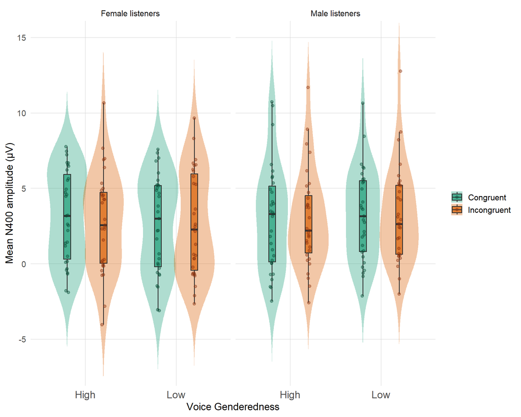

```r
plot_data_sexuality <- exp1_data_sexuality %>%
  group_by(ParticipantID, PtpGender, VoiceGenderedness, Congruency) %>%
  summarise(mean_value = mean(value, na.rm = TRUE), .groups = "drop")

p3a <- ggplot(
  plot_data_sexuality,
  aes(x = VoiceGenderedness, y = mean_value, fill = as_plot_congruency(Congruency))
) +
  geom_violin(
    position = position_dodge(0.8),
    trim = FALSE,
    alpha = 0.35,
    color = NA
  ) +
  geom_boxplot(
    position = position_dodge(0.8),
    width = 0.15,
    outlier.shape = NA,
    alpha = 0.7
  ) +
  geom_jitter(
    aes(color = as_plot_congruency(Congruency)),
    position = position_jitterdodge(
      jitter.width = 0.08,
      dodge.width = 0.8
    ),
    alpha = 0.4,
    size = 1.6
  ) +
  scale_fill_manual(values = CONGRUENCY_COLORS, breaks = CONGRUENCY_PLOT_LEVELS) +
  scale_color_manual(values = CONGRUENCY_DOT_COLORS, breaks = CONGRUENCY_PLOT_LEVELS) +
  facet_wrap(
    ~ PtpGender,
    nrow = 1,
    labeller = as_labeller(c("Female" = "Female listeners", "Male" = "Male listeners"))
  ) +
  coord_cartesian(ylim = c(-7, 15)) +
  labs(
    subtitle = NULL,
    x = "Voice Genderedness",
    y = "Mean N400 amplitude (µV)",
    fill = NULL,
    color = NULL
  ) +
  create_plot_theme(base_size = BaseSize) +
  theme(
    axis.text.x = element_text(size = 14),
    legend.position = "right"
  )

p3a
```

```r
# ggsave("./Figures/Exp1_sexuality_violin_svg_p3a.svg", plot = p3a, device = "svg",
#        width = 8, height = 6, units = "in")
```

### 3.4.2 Post-hoc analysis: Focusing on trials with female participants hearing highly gendered voices

Results from Analysis 1 show a trend of Congruency effect in the predicted direction, although not significant. In this post-hod analysis, we focus on trials with female participants hearing highly gendered voices and test if the effect of Congruency interacts with trial order.

#### 3.4.2.1 Congruency × Trial Order

```r
exp1_data_sexuality_female_high <- exp1_data_sexuality %>%
  filter(VoiceGenderedness == "High") %>%
  filter(PtpGender == "Female") %>%
  mutate(Order_c = Order - mean(Order)) # Re-center Order for this subset

exp1_model_sexuality_female_high <- run_lmer_model(
  value ~ Congruency * Order_c +
    (1 | ParticipantID) + (1 | WordID) + (1 | ChLabel),
  data = exp1_data_sexuality_female_high
)
```

```
## Linear mixed model fit by maximum likelihood . t-tests use Satterthwaite's
##   method [lmerModLmerTest]
## Formula: formula
##    Data: data
## Control: control
##
##       AIC       BIC    logLik -2*log(L)  df.resid
##  188256.0  188321.4  -94120.0  188240.0     26332
##
## Scaled residuals:
##     Min      1Q  Median      3Q     Max
## -5.3926 -0.6597 -0.0040  0.6480  6.2732
##
## Random effects:
##  Groups        Name        Variance Std.Dev.
##  WordID        (Intercept)  3.9129  1.978
##  ParticipantID (Intercept)  9.2619  3.043
##  ChLabel       (Intercept)  0.1156  0.340
##  Residual                  72.8917  8.538
## Number of obs: 26340, groups:  WordID, 160; ParticipantID, 31; ChLabel, 6
##
## Fixed effects:
##                          Estimate    Std. Error            df t value
## (Intercept)             2.9870665     0.5876684    39.2009073   5.083
## Congruency1            -0.4166286     0.1056543 26188.6548125  -3.943
## Order_c                -0.0089814     0.0004692 26207.6482973 -19.142
## Congruency1:Order_c     0.0025745     0.0009245 26201.6520470   2.785
##                       Pr(>|t|)
## (Intercept)         0.00000952 ***
## Congruency1         0.00008057 ***
## Order_c                < 2e-16 ***
## Congruency1:Order_c    0.00536 **
## ---
## Signif. codes:  0 '***' 0.001 '**' 0.01 '*' 0.05 '.' 0.1 ' ' 1
##
## Correlation of Fixed Effects:
##             (Intr) Cngrn1 Ordr_c
## Congruency1  0.000
## Order_c     -0.002  0.001
## Cngrncy1:O_  0.000 -0.003  0.005
##
## Analysis of Deviance Table (Type III Wald chisquare tests)
##
## Response: value
##                       Chisq Df   Pr(>Chisq)
## (Intercept)         25.8360  1 0.0000003717 ***
## Congruency          15.5498  1 0.0000803620 ***
## Order_c            366.4272  1    < 2.2e-16 ***
## Congruency:Order_c   7.7541  1     0.005359 **
## ---
## Signif. codes:  0 '***' 0.001 '**' 0.01 '*' 0.05 '.' 0.1 ' ' 1
```

```r
# Augment the random effects structure
exp1_model_sexuality_female_high <- run_lmer_model(
  value ~ Congruency * Order_c +
    (1 + Congruency * Order_c | ParticipantID) + (1 + Congruency * Order_c | WordID) + (1 | ChLabel),
  data = exp1_data_sexuality_female_high,
  auto_simplify = TRUE,
  time_limit = 600
)
```

```
## ======================================================
## === Searching for optimal RE structure
## === Fixed effects: value ~ Congruency * Order_c
## ======================================================
```

```
## Testing 7 candidate RE structure(s)...
##
## [1/7] maximal (correlated)
##        RE:  (1 + Congruency + Order_c + Congruency:Order_c | ParticipantID) + (1 + Congruency + Order_c + Congruency:Order_c | WordID) + (1 | ChLabel)
##   -> Timed out after 600 s. Skipping.
##
## [2/7] maximal (uncorrelated)
##        RE:  (1 | ParticipantID) + (0 + Congruency | ParticipantID) + (0 + Order_c | ParticipantID) + (0 + Congruency:Order_c | ParticipantID) + (1 | WordID) + (0 + Congruency | WordID) + (0 + Order_c | WordID) + (0 + Congruency:Order_c | WordID) + (1 | ChLabel)
##   -> Timed out after 600 s. Skipping.
##
## [3/7] WordID: main effects only (correlated)
##        RE:  (1 + Congruency + Order_c + Congruency:Order_c | ParticipantID) + (1 + Congruency + Order_c | WordID) + (1 | ChLabel)
##   -> Timed out after 600 s. Skipping.
##
## [4/7] WordID: main effects only (uncorrelated)
##        RE:  (1 | ParticipantID) + (0 + Congruency | ParticipantID) + (0 + Order_c | ParticipantID) + (0 + Congruency:Order_c | ParticipantID) + (1 | WordID) + (0 + Congruency | WordID) + (0 + Order_c | WordID) + (1 | ChLabel)
##   -> Timed out after 600 s. Skipping.
##
## [5/7] ParticipantID: main effects only (correlated)
##        RE:  (1 + Congruency + Order_c | ParticipantID) + (1 + Congruency + Order_c | WordID) + (1 | ChLabel)
##   -> Timed out after 600 s. Skipping.
##
## [6/7] ParticipantID: main effects only (uncorrelated)
##        RE:  (1 | ParticipantID) + (0 + Congruency | ParticipantID) + (0 + Order_c | ParticipantID) + (1 | WordID) + (0 + Congruency | WordID) + (0 + Order_c | WordID) + (1 | ChLabel)
##   -> Timed out after 600 s. Skipping.
##
## [7/7] intercepts only
##        RE:  (1 | ParticipantID) + (1 | WordID) + (1 | ChLabel)
##   -> Singular: FALSE | Gradient: (unavailable) | Optimizer warnings: FALSE
##   -> OPTIMAL: converged. Using this RE structure.
##
##   Re-fitting with REML = TRUE...
## ======================================================
## === Optimal RE structure found: intercepts only
## ======================================================
##
## Linear mixed model fit by REML. t-tests use Satterthwaite's method [
## lmerModLmerTest]
## Formula: refit_formula
##    Data: data
```

[output cut: 31 more lines]

```
##             (Intr) Cngrn1 Ordr_c
## Congruency1  0.000
## Order_c     -0.002  0.001
## Cngrncy1:O_  0.000 -0.003  0.005
##
## Analysis of Deviance Table (Type III Wald chisquare tests)
##
## Response: value
##                       Chisq Df   Pr(>Chisq)
## (Intercept)         25.1736  1 0.0000005239 ***
## Congruency          15.5488  1 0.0000804036 ***
## Order_c            366.3924  1    < 2.2e-16 ***
## Congruency:Order_c   7.7535  1     0.005361 **
## ---
## Signif. codes:  0 '***' 0.001 '**' 0.01 '*' 0.05 '.' 0.1 ' ' 1
```

```r
# Post-hoc: simple effect of Congruency

posthoc <- emmeans(exp1_model_sexuality_female_high, pairwise ~ Congruency)

cat("\n=== Estimated Marginal Means ===\n")
```

```
##
## === Estimated Marginal Means ===
```

```r
print(posthoc$emmeans)
```

```
##  Congruency  emmean    SE  df asymp.LCL asymp.UCL
##  Incongruent   2.78 0.598 Inf      1.61      3.95
##  Congruent     3.20 0.598 Inf      2.02      4.37
##
## Degrees-of-freedom method: asymptotic
## Confidence level used: 0.95
```

```r
cat("\n=== Pairwise Comparisons (Congruent vs Incongruent) ===\n")
```

```
##
## === Pairwise Comparisons (Congruent vs Incongruent) ===
```

```r
print(posthoc$contrasts)
```

```
##  contrast                estimate    SE  df z.ratio p.value
##  Incongruent - Congruent   -0.417 0.106 Inf  -3.943 <0.0001
##
## Degrees-of-freedom method: asymptotic
```

```r
# Slope analysis
cat("\n=== Slope Analysis ===\n")
```

```
##
## === Slope Analysis ===
```

```r
analyze_trends(exp1_model_sexuality_female_high, ~ Congruency, var = "Order_c")
```

```
##
## Slope estimates:
##  Congruency  Order_c.trend       SE  df asymp.LCL asymp.UCL z.ratio p.value
##  Incongruent      -0.00769 0.000660 Inf  -0.00899  -0.00640 -11.655 <0.0001
##  Congruent        -0.01027 0.000657 Inf  -0.01156  -0.00898 -15.625 <0.0001
##
## Degrees-of-freedom method: asymptotic
## Confidence level used: 0.95
##
## Slope contrasts:
##  contrast                estimate       SE  df z.ratio p.value
##  Incongruent - Congruent  0.00257 0.000925 Inf   2.785  0.0054
##
## Degrees-of-freedom method: asymptotic
```

```
## $trends
##  Congruency  Order_c.trend       SE  df asymp.LCL asymp.UCL
##  Incongruent      -0.00769 0.000660 Inf  -0.00899  -0.00640
##  Congruent        -0.01027 0.000657 Inf  -0.01156  -0.00898
##
## Degrees-of-freedom method: asymptotic
## Confidence level used: 0.95
##
## $contrasts
##  contrast                estimate       SE  df z.ratio p.value
##  Incongruent - Congruent  0.00257 0.000925 Inf   2.785  0.0054
##
## Degrees-of-freedom method: asymptotic
```

```r
# Quantile analysis
cat("\n=== Quantile Analysis ===\n")
```

```
##
## === Quantile Analysis ===
```

```r
quantile_results <- analyze_quantiles(
  exp1_model_sexuality_female_high,
  exp1_data_sexuality_female_high,
  specs = ~ Congruency,
  var = "Order_c"
)
```

```
##
##  25% quantile ( Order_c  = -98.13212 ):
```

```
##  Congruency  emmean    SE  df asymp.LCL asymp.UCL
##  Incongruent   3.53 0.601 Inf      2.36      4.71
##  Congruent     4.20 0.601 Inf      3.02      5.38
##
## Degrees-of-freedom method: asymptotic
## Confidence level used: 0.95
##  contrast                estimate    SE  df z.ratio p.value
##  Incongruent - Congruent   -0.669 0.139 Inf  -4.798 <0.0001
##
## Degrees-of-freedom method: asymptotic
##
##  50% quantile ( Order_c  = 2.867882 ):
```

```
##  Congruency  emmean    SE  df asymp.LCL asymp.UCL
##  Incongruent   2.76 0.598 Inf      1.59      3.93
##  Congruent     3.17 0.598 Inf      1.99      4.34
##
## Degrees-of-freedom method: asymptotic
## Confidence level used: 0.95
##  contrast                estimate    SE  df z.ratio p.value
##  Incongruent - Congruent   -0.409 0.106 Inf  -3.872  0.0001
##
## Degrees-of-freedom method: asymptotic
##
##  75% quantile ( Order_c  = 98.86788 ):
```

```
##  Congruency  emmean    SE  df asymp.LCL asymp.UCL
##  Incongruent   2.02 0.601 Inf      0.84      3.20
##  Congruent     2.18 0.601 Inf      1.00      3.36
##
## Degrees-of-freedom method: asymptotic
## Confidence level used: 0.95
##  contrast                estimate   SE  df z.ratio p.value
##  Incongruent - Congruent   -0.162 0.14 Inf  -1.162  0.2452
##
## Degrees-of-freedom method: asymptotic
##
##  100% quantile ( Order_c  = 195.8679 ):
```

```
##  Congruency  emmean    SE  df asymp.LCL asymp.UCL
##  Incongruent   1.27 0.611 Inf    0.0735      2.47
##  Congruent     1.18 0.611 Inf   -0.0137      2.38
##
## Degrees-of-freedom method: asymptotic
## Confidence level used: 0.95
##  contrast                estimate    SE  df z.ratio p.value
##  Incongruent - Congruent   0.0876 0.209 Inf   0.418  0.6756
##
## Degrees-of-freedom method: asymptotic
```

Plot the Congruency effect across Order_c among trials with female participants hearing highly gendered voices (Fig.4).

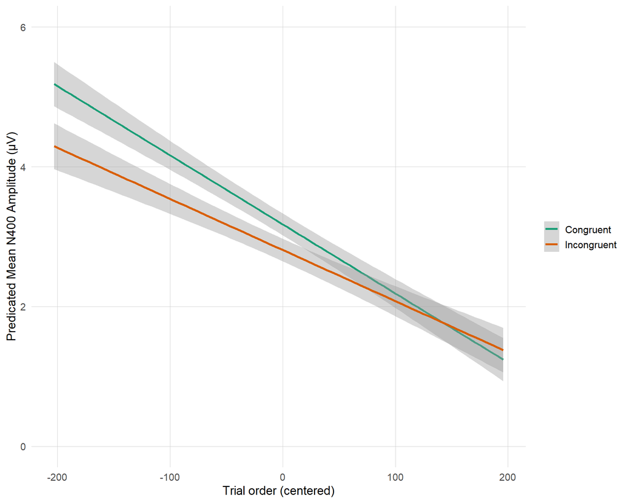

```r
p4 <- create_adaptation_plot(
  data = exp1_data_sexuality_female_high,
  x_var = "Order_c",
  title = NULL,
  subtitle = NULL,
  ylim = c(0, 6)
  ) +
  labs(x = "Trial order (centered)",
    y = "Predicated Mean N400 Amplitude (μV)") +
  labs(color = NULL) +
  theme(legend.position = "right")
p4
```

```r
# ggsave("./Figures/Exp1_female_highlygendered_order_svg.svg", plot = p4, device = "svg", width = 8, height = 4, units = "in")
```